# Intratumoral heterogeneity in murine injection model

Sara Söderqvist and Annika Viljamaa

2025-03-11

## Load required packages

```r
library(dplyr)
library(rstatix)
```

```r
library(ggplot2)
library(ggpubr)
library(RColorBrewer)
library(pheatmap)
library(stats)
library(ggfortify)
library(factoextra)
library(grid)
library(ComplexHeatmap)
```

[output not shown]

```r
library(tidyverse)
library(ggthemes)
library(reshape2)
```

```r
library(corrplot)
```

This script explores how the markers Galectin-4, HMGA2 and GATA6 are enriched in tumor cells in different tissue locations in an injection model of murine PDAC.

Transparancy note: An issue discovered after the previous script for this injection model was made public in GitHub, used for teh preprint, is that cells that were completely negative for quantified marker (at that time, only HMGA2) were not included in the wilcoxon testing also displayed in the boxplot. This is adjusted in the current script.

We aimed here to rather use the markers as a panel that can be used to call an overall subtype in the ROIs, than single markers on their own.

## Import the data

```r
setwd("/Users/sara.soderqvist/Library/CloudStorage/OneDrive-KarolinskaInstitutet/Writing_/Adaptive PDAC paper/Code/source data files to read in/In vivo") # adjust the working directory

HMGA2.data_ori <- read.table('read in_in vivo_injection model.tsv',
                                  sep = '\t', header = T)
dim(HMGA2.data_ori) #27 860 observations (=Cells) in total
```

[1] 27860 12

```r
knitr::kable(head(HMGA2.data_ori))
```

| Image | Object.ID | Object.type | Name | Classification | Parent | ROI | Nucleus..DAPI.mean | Nucleus..HMGA2.mean | Cell..Galectin.4.mean | Cell..Vimentin.mean | Nucleus..GATA6.mean |
| --- | --- | --- | --- | --- | --- | --- | --- | --- | --- | --- | --- |
| HA_29_StromaA | 0685f1e5-48ce-4260-8ead-4a23407ce0df | Cell | NA | HMGA2: Negative | Annotation (stromal_invasion_1) | Polygon | 732.5444 | 144.6555 | NA | NA | NA |
| HA_29_StromaA | 282b7983-eece-4646-9b65-78b9ea6124c5 | Cell | NA | HMGA2: Negative | Annotation (stromal_invasion_1) | Polygon | 1394.4332 | 144.7038 | NA | NA | NA |
| HA_29_StromaA | 401246d7-183a-4292-a28b-4f81683ad4e4 | Cell | NA | HMGA2: Negative | Annotation (stromal_invasion_1) | Polygon | 1388.3823 | 146.9265 | NA | NA | NA |
| HA_29_StromaA | fb07d294-de23-48ff-8803-5ee37f151435 | Cell | NA | HMGA2: Negative | Annotation (stromal_invasion_1) | Polygon | 1178.6666 | 148.4310 | NA | NA | NA |
| HA_29_StromaA | f960b0a1-162c-4600-98dc-0d1555ca7341 | Cell | NA | HMGA2: Negative | Annotation (stromal_invasion_1) | Polygon | 1526.1434 | 149.2826 | NA | NA | NA |
| HA_29_StromaA | f88d64be-d5cf-4eeb-adf0-ea586b398ef9 | Cell | NA | HMGA2: Positive | Annotation (stromal_invasion_1) | Polygon | 1604.3833 | 1007.2432 | NA | NA | NA |

## Data modification

```r
# Subset the data to only relevant information
og.data <- HMGA2.data_ori %>%
  select(Image, Classification, Parent)%>%
  data.frame()

HMGA2.posdata <- og.data[og.data$Classification =="HMGA2: Positive", ]
HMGA2.negdata <- og.data[og.data$Classification =="HMGA2: Negative", ]
HMGA2.data <- rbind(HMGA2.posdata, HMGA2.negdata) # these are now all cells wither positive or negative for HMGA2, n = 11 233 cells.

colnames(HMGA2.data) <- c('Image', 'HMGA2_status', 'Parent')
HMGA2.data$Image_id <- gsub("\\..*","",HMGA2.data$Image)

HMGA2.data$Mouse_id <- gsub("HA_","",HMGA2.data$Image)
HMGA2.data$Mouse_id <- gsub("H_","",HMGA2.data$Mouse_id) # addition after name changing..
HMGA2.data$Mouse_id <- gsub("_.*","",HMGA2.data$Mouse_id)
unique(HMGA2.data$Mouse_id) # only case number left
```

[1] “29” “28” “27” “30”

```r
HMGA2.data$HMGA2_status <- gsub("HMGA2: ","",HMGA2.data$HMGA2_status)
unique(HMGA2.data$HMGA2_status) # only status information left
```

[1] “Positive” “Negative”

```r
#create a new column to have plain info on the ROI (stroma/acinar aka lobular)
HMGA2.data$invasion_type <- gsub("_i.*","",HMGA2.data$Parent)
HMGA2.data$invasion_type <- gsub("Annotation \\(","",HMGA2.data$invasion_type)

unique(HMGA2.data$invasion_type)
```

[1] “stromal” “acinar”

```r
# convertion & new columns format
knitr::kable(head(HMGA2.data))
```

|  | Image | HMGA2_status | Parent | Image_id | Mouse_id | invasion_type |
| --- | --- | --- | --- | --- | --- | --- |
| 6 | HA_29_StromaA | Positive | Annotation (stromal_invasion_1) | HA_29_StromaA | 29 | stromal |
| 8 | HA_29_StromaA | Positive | Annotation (stromal_invasion_1) | HA_29_StromaA | 29 | stromal |
| 9 | HA_29_StromaA | Positive | Annotation (stromal_invasion_1) | HA_29_StromaA | 29 | stromal |
| 10 | HA_29_StromaA | Positive | Annotation (stromal_invasion_1) | HA_29_StromaA | 29 | stromal |
| 11 | HA_29_StromaA | Positive | Annotation (stromal_invasion_1) | HA_29_StromaA | 29 | stromal |
| 12 | HA_29_StromaA | Positive | Annotation (stromal_invasion_1) | HA_29_StromaA | 29 | stromal |

## Details

### Summary/ROI

```r
HMGA2_summary <- HMGA2.data %>%
  select(Image_id, Mouse_id, invasion_type, Parent)%>%
  group_by(Image_id, Mouse_id, invasion_type, Parent)%>%
  dplyr::summarise(Detections = n())
```

```
## You can override using the `.groups` argument.
```

```r
HMGA2_pos <- HMGA2.data %>%
  filter(HMGA2_status == 'Positive')%>%
  select(Image_id, Mouse_id, invasion_type, Parent)%>%
  group_by(Image_id, Mouse_id, invasion_type, Parent)%>%
  dplyr::summarise(HMGA2pos = n())
```

```
## You can override using the `.groups` argument.
```

```r
HMGA2_Rsummary <- merge(x = HMGA2_summary, y = HMGA2_pos, id = c('Mouse_id', 'Parent'), all = TRUE)
# if NA occurs here in the HMGA2pos column, it means that that ROIs had 0 positive tumor cells there, add that:
HMGA2_Rsummary[is.na(HMGA2_Rsummary)] <- 0

HMGA2_Rsummary <- HMGA2_Rsummary%>%
  mutate(HMGApos_percent = HMGA2pos/Detections*100)%>%
  data.frame()

knitr::kable(HMGA2_Rsummary)
```

| Image_id | Mouse_id | invasion_type | Parent | Detections | HMGA2pos | HMGApos_percent |
| --- | --- | --- | --- | --- | --- | --- |
| H_30_LobuleA | 30 | acinar | Annotation (acinar_invasion_1) | 225 | 83 | 36.8888889 |
| H_30_LobuleA | 30 | acinar | Annotation (acinar_invasion_3) | 251 | 30 | 11.9521912 |
| H_30_LobuleA | 30 | stromal | Annotation (stromal_invasion_1) | 586 | 188 | 32.0819113 |
| H_30_LobuleA | 30 | stromal | Annotation (stromal_invasion_2) | 613 | 288 | 46.9820555 |
| H_30_LobuleA | 30 | stromal | Annotation (stromal_invasion_3) | 155 | 112 | 72.2580645 |
| H_30_LobuleA | 30 | stromal | Annotation (stromal_invasion_4) | 400 | 188 | 47.0000000 |
| HA_27_LobuleA | 27 | acinar | Annotation (acinar_invasion_1) | 61 | 42 | 68.8524590 |
| HA_27_LobuleA | 27 | acinar | Annotation (acinar_invasion_2) | 110 | 73 | 66.3636364 |
| HA_27_LobuleA | 27 | acinar | Annotation (acinar_invasion_3) | 35 | 0 | 0.0000000 |
| HA_27_LobuleA | 27 | acinar | Annotation (acinar_invasion_4) | 299 | 8 | 2.6755853 |
| HA_27_LobuleA | 27 | acinar | Annotation (acinar_invasion_5) | 198 | 1 | 0.5050505 |
| HA_27_LobuleA | 27 | stromal | Annotation (stromal_invasion_1) | 262 | 220 | 83.9694656 |
| HA_27_LobuleA | 27 | stromal | Annotation (stromal_invasion_2) | 321 | 244 | 76.0124611 |
| HA_28_LobuleA | 28 | acinar | Annotation (acinar_invasion_1) | 222 | 0 | 0.0000000 |
| HA_28_LobuleA | 28 | stromal | Annotation (stromal_invasion_1) | 152 | 1 | 0.6578947 |
| HA_28_LobuleB | 28 | stromal | Annotation (stromal_invasion_1_A) | 193 | 0 | 0.0000000 |
| HA_28_LobuleB | 28 | stromal | Annotation (stromal_invasion_2_A) | 161 | 0 | 0.0000000 |
| HA_28_LobuleC | 28 | acinar | Annotation (acinar_invasion_1) | 230 | 6 | 2.6086957 |
| HA_28_LobuleC | 28 | acinar | Annotation (acinar_invasion_10) | 19 | 2 | 10.5263158 |
| HA_28_LobuleC | 28 | acinar | Annotation (acinar_invasion_11) | 168 | 1 | 0.5952381 |
| HA_28_LobuleC | 28 | acinar | Annotation (acinar_invasion_12) | 25 | 2 | 8.0000000 |
| HA_28_LobuleC | 28 | acinar | Annotation (acinar_invasion_13) | 56 | 1 | 1.7857143 |
| HA_28_LobuleC | 28 | acinar | Annotation (acinar_invasion_14) | 113 | 1 | 0.8849558 |
| HA_28_LobuleC | 28 | acinar | Annotation (acinar_invasion_15) | 86 | 9 | 10.4651163 |
| HA_28_LobuleC | 28 | acinar | Annotation (acinar_invasion_16) | 98 | 0 | 0.0000000 |
| HA_28_LobuleC | 28 | acinar | Annotation (acinar_invasion_17) | 211 | 10 | 4.7393365 |
| HA_28_LobuleC | 28 | acinar | Annotation (acinar_invasion_18) | 67 | 1 | 1.4925373 |
| HA_28_LobuleC | 28 | acinar | Annotation (acinar_invasion_2) | 72 | 15 | 20.8333333 |
| HA_28_LobuleC | 28 | acinar | Annotation (acinar_invasion_3) | 61 | 1 | 1.6393443 |
| HA_28_LobuleC | 28 | acinar | Annotation (acinar_invasion_4) | 331 | 7 | 2.1148036 |
| HA_28_LobuleC | 28 | acinar | Annotation (acinar_invasion_5) | 103 | 34 | 33.0097087 |
| HA_28_LobuleC | 28 | acinar | Annotation (acinar_invasion_6) | 68 | 10 | 14.7058824 |
| HA_28_LobuleC | 28 | acinar | Annotation (acinar_invasion_7) | 32 | 2 | 6.2500000 |
| HA_28_LobuleC | 28 | acinar | Annotation (acinar_invasion_8) | 48 | 13 | 27.0833333 |
| HA_28_LobuleC | 28 | acinar | Annotation (acinar_invasion_9) | 88 | 4 | 4.5454545 |
| HA_28_LobuleC | 28 | stromal | Annotation (stromal_invasion_1) | 42 | 14 | 33.3333333 |
| HA_28_LobuleC | 28 | stromal | Annotation (stromal_invasion_2) | 152 | 0 | 0.0000000 |
| HA_28_LobuleC | 28 | stromal | Annotation (stromal_invasion_3) | 352 | 8 | 2.2727273 |
| HA_28_LobuleC | 28 | stromal | Annotation (stromal_invasion_4) | 184 | 13 | 7.0652174 |
| HA_28_LobuleC | 28 | stromal | Annotation (stromal_invasion_6) | 458 | 68 | 14.8471616 |
| HA_28_LobuleC | 28 | stromal | Annotation (stromal_invasion_7) | 571 | 35 | 6.1295972 |
| HA_28_LobuleC | 28 | stromal | Annotation (stromal_invasion_8) | 418 | 37 | 8.8516746 |
| HA_28_LobuleD | 28 | acinar | Annotation (acinar_invasion_1) | 183 | 88 | 48.0874317 |
| HA_29_StromaA | 29 | stromal | Annotation (stromal_invasion_1) | 421 | 339 | 80.5225653 |
| HA_29_StromaA | 29 | stromal | Annotation (stromal_invasion_2) | 1742 | 699 | 40.1262916 |
| HA_29_StromaA | 29 | stromal | Annotation (stromal_invasion_3) | 590 | 431 | 73.0508475 |

### Summary/mouse_id

```r
ROIs <- HMGA2_Rsummary %>%
  select(Mouse_id, invasion_type)%>%
  group_by(Mouse_id, invasion_type)%>%
  dplyr::summarise(ROIs = n())
HMGA2_Msummary <- HMGA2.data %>%
  select(Mouse_id, invasion_type)%>%
  group_by(Mouse_id, invasion_type)%>%
  dplyr::summarise(Detections = n())
HMGA2_pos <- HMGA2.data %>%
  filter(HMGA2_status == 'Positive')%>%
  select(Mouse_id, invasion_type)%>%
  group_by(Mouse_id, invasion_type)%>%
  dplyr::summarise(HMGA2pos = n())
HMGA2_Msummary <- merge(x = HMGA2_Msummary, y = HMGA2_pos, id = c('Mouse_id'))
HMGA2_Msummary <- merge(x = HMGA2_Msummary, y = ROIs, id = c('Mouse_id', 'invasion_type'))
HMGA2_Msummary <- HMGA2_Msummary%>%
  mutate(HMGApos_percent = HMGA2pos/Detections*100)%>%
  data.frame()

knitr::kable(HMGA2_Msummary)
```

| Mouse_id | invasion_type | Detections | HMGA2pos | ROIs | HMGApos_percent |
| --- | --- | --- | --- | --- | --- |
| 27 | acinar | 703 | 124 | 5 | 17.638691 |
| 27 | stromal | 583 | 464 | 2 | 79.588336 |
| 28 | acinar | 2281 | 207 | 20 | 9.074967 |
| 28 | stromal | 2683 | 176 | 10 | 6.559821 |
| 29 | stromal | 2753 | 1469 | 3 | 53.359971 |
| 30 | acinar | 476 | 113 | 2 | 23.739496 |
| 30 | stromal | 1754 | 776 | 4 | 44.241733 |

## Statistical testing for HMGA2 only

```r
# Wilcox test (non-paired)
res.wil <-  HMGA2_Rsummary %>%
  wilcox_test(HMGApos_percent~invasion_type)%>%
  adjust_pvalue(method = 'BH')%>%
  add_significance()
res.wil <- res.wil %>% add_xy_position(x = 'invasion_type')
res.wil
```

```
## # A tibble: 1 × 13
##   .y.             group1 group2    n1    n2 statistic      p  p.adj p.adj.signif
##   <chr>           <chr>  <chr>  <int> <int>     <dbl>  <dbl>  <dbl> <chr>
## 1 HMGApos_percent acinar strom…    27    19      176. 0.0758 0.0758 ns
## # ℹ 4 more variables: y.position <dbl>, groups <named list>, xmin <dbl>,
## #   xmax <dbl>
```

## Boxplot of HMGA2

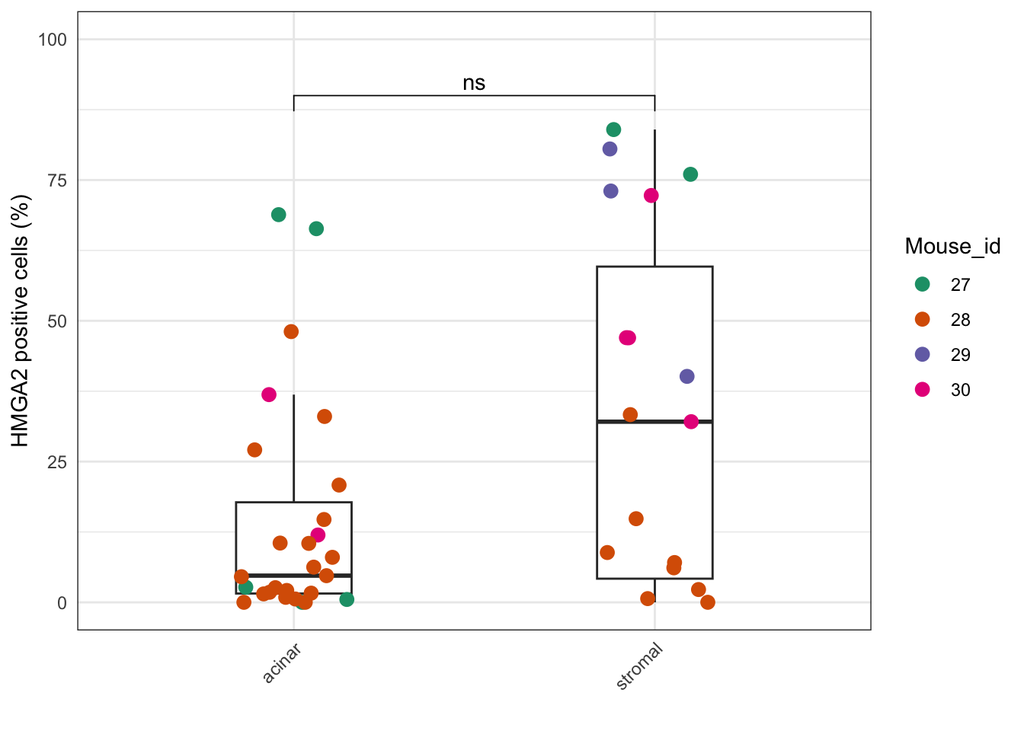

```r
# plot
box_HMGA2 <- HMGA2_Rsummary%>%
  ggplot(aes(x = invasion_type, y = HMGApos_percent))+
  geom_boxplot(width = 0.32, outlier.shape = NA)+
  geom_jitter(aes(color = Mouse_id), alpha = 1, position=position_jitter(0.15), size = 2.8, seed = 1.5)+
  scale_color_brewer(palette = 'Dark2')+
          labs(x = '', y = 'HMGA2 positive cells (%)')+
  theme_bw()+
  theme(legend.position = "right", axis.text.x = element_text(angle = 45, vjust = 1, hjust=1),
        axis.ticks = element_blank())+
    stat_pvalue_manual(res.wil, label = 'p.adj.signif',
                     y.position = 90)+
  ylim(0,100)
box_HMGA2
```

```r
hmga2_split <- split(HMGA2_Rsummary, f = HMGA2_Rsummary$Mouse_id)

lapply(hmga2_split, function (a) {
  b <- split(a, f = a$Image_id)
  lapply(b, function(c) {
    unique(c$Parent)
  })
}
)
```

```
## $`27`
## $`27`$HA_27_LobuleA
## [1] "Annotation (acinar_invasion_1)"  "Annotation (acinar_invasion_2)"
## [3] "Annotation (acinar_invasion_3)"  "Annotation (acinar_invasion_4)"
## [5] "Annotation (acinar_invasion_5)"  "Annotation (stromal_invasion_1)"
## [7] "Annotation (stromal_invasion_2)"
##
##
## $`28`
## $`28`$HA_28_LobuleA
## [1] "Annotation (acinar_invasion_1)"  "Annotation (stromal_invasion_1)"
##
## $`28`$HA_28_LobuleB
## [1] "Annotation (stromal_invasion_1_A)" "Annotation (stromal_invasion_2_A)"
##
## $`28`$HA_28_LobuleC
##  [1] "Annotation (acinar_invasion_1)"  "Annotation (acinar_invasion_10)"
##  [3] "Annotation (acinar_invasion_11)" "Annotation (acinar_invasion_12)"
##  [5] "Annotation (acinar_invasion_13)" "Annotation (acinar_invasion_14)"
##  [7] "Annotation (acinar_invasion_15)" "Annotation (acinar_invasion_16)"
##  [9] "Annotation (acinar_invasion_17)" "Annotation (acinar_invasion_18)"
## [11] "Annotation (acinar_invasion_2)"  "Annotation (acinar_invasion_3)"
## [13] "Annotation (acinar_invasion_4)"  "Annotation (acinar_invasion_5)"
## [15] "Annotation (acinar_invasion_6)"  "Annotation (acinar_invasion_7)"
## [17] "Annotation (acinar_invasion_8)"  "Annotation (acinar_invasion_9)"
## [19] "Annotation (stromal_invasion_1)" "Annotation (stromal_invasion_2)"
## [21] "Annotation (stromal_invasion_3)" "Annotation (stromal_invasion_4)"
## [23] "Annotation (stromal_invasion_6)" "Annotation (stromal_invasion_7)"
## [25] "Annotation (stromal_invasion_8)"
##
## $`28`$HA_28_LobuleD
## [1] "Annotation (acinar_invasion_1)"
##
##
## $`29`
## $`29`$HA_29_StromaA
## [1] "Annotation (stromal_invasion_1)" "Annotation (stromal_invasion_2)"
## [3] "Annotation (stromal_invasion_3)"
##
##
## $`30`
## $`30`$H_30_LobuleA
## [1] "Annotation (acinar_invasion_1)"  "Annotation (acinar_invasion_3)"
## [3] "Annotation (stromal_invasion_1)" "Annotation (stromal_invasion_2)"
## [5] "Annotation (stromal_invasion_3)" "Annotation (stromal_invasion_4)"
```

# Gal4 quantification

Compared to the HMGA2 quantification, two ROIs could not be identified. Level differences in the sections rendered no tumor in these two regions.

## Data modification

```r
# Subset the data to only relevant information

Gal4.posdata <- og.data[og.data$Classification =="Gal4: Positive", ]
Gal4.negdata <- og.data[og.data$Classification =="Gal4: Negative", ]
Gal4.data <- rbind(Gal4.posdata, Gal4.negdata) # these are now all cells that are either Gal4+ or Gal4-, n = 8 485 cells.
dim(Gal4.data)
```

[1] 8485 3

```r
colnames(Gal4.data) <- c('Image', 'Gal4_status', 'Parent')
Gal4.data$Image_id <- gsub("\\..*","",Gal4.data$Image)

Gal4.data$Mouse_id <- gsub("GV_","",Gal4.data$Image)
Gal4.data$Mouse_id <- gsub("_.*","",Gal4.data$Mouse_id)
unique(Gal4.data$Mouse_id) # only case number left
```

[1] “27” “30” “28” “29”

```r
Gal4.data$Gal4_status <- gsub("Gal4: ","",Gal4.data$Gal4_status)
unique(Gal4.data$Gal4_status) # only status information left
```

[1] “Positive” “Negative”

```r
#create a new column to have plain info on the ROI (stroma/acinar)
Gal4.data$invasion_type <- gsub("_i.*","",Gal4.data$Parent)
Gal4.data$invasion_type <- gsub("Annotation \\(","",Gal4.data$invasion_type)
unique(Gal4.data$invasion_type)
```

[1] “acinar” “stromal”

```r
# convertion & new columns look as they should
knitr::kable(head(Gal4.data))
```

|  | Image | Gal4_status | Parent | Image_id | Mouse_id | invasion_type |
| --- | --- | --- | --- | --- | --- | --- |
| 11237 | GV_27_LobuleA | Positive | Annotation (acinar_invasion_1) | GV_27_LobuleA | 27 | acinar |
| 11242 | GV_27_LobuleA | Positive | Annotation (acinar_invasion_1) | GV_27_LobuleA | 27 | acinar |
| 11243 | GV_27_LobuleA | Positive | Annotation (acinar_invasion_1) | GV_27_LobuleA | 27 | acinar |
| 11245 | GV_27_LobuleA | Positive | Annotation (acinar_invasion_1) | GV_27_LobuleA | 27 | acinar |
| 11264 | GV_27_LobuleA | Positive | Annotation (acinar_invasion_1) | GV_27_LobuleA | 27 | acinar |
| 11268 | GV_27_LobuleA | Positive | Annotation (acinar_invasion_1) | GV_27_LobuleA | 27 | acinar |

## Details

### Summary/ROI

```r
Gal4_summary <- Gal4.data %>%
  select(Image_id, Mouse_id, invasion_type, Parent)%>%
  group_by(Image_id, Mouse_id, invasion_type, Parent)%>%
  dplyr::summarise(Detections = n())
```

```
## You can override using the `.groups` argument.
```

```r
Gal4_pos <- Gal4.data %>%
  filter(Gal4_status == 'Positive')%>%
  select(Image_id, Mouse_id, invasion_type, Parent)%>%
  group_by(Image_id, Mouse_id, invasion_type, Parent)%>%
  dplyr::summarise(Gal4pos = n())
```

```
## You can override using the `.groups` argument.
```

```r
Gal4_Rsummary <- merge(x = Gal4_summary, y = Gal4_pos, id = c('Mouse_id', 'Parent'), all = TRUE)
# if NA occurs here in the Gal4pos column, it means that that ROIs had 0 positive tumor cells there, add that:
Gal4_Rsummary[is.na(Gal4_Rsummary)] <- 0

Gal4_Rsummary <- Gal4_Rsummary%>%
  mutate(Gal4pos_percent = Gal4pos/Detections*100)%>%
  data.frame()

knitr::kable(Gal4_Rsummary)
```

| Image_id | Mouse_id | invasion_type | Parent | Detections | Gal4pos | Gal4pos_percent |
| --- | --- | --- | --- | --- | --- | --- |
| GV_27_LobuleA | 27 | acinar | Annotation (acinar_invasion_1) | 65 | 17 | 26.1538462 |
| GV_27_LobuleA | 27 | acinar | Annotation (acinar_invasion_2) | 103 | 1 | 0.9708738 |
| GV_27_LobuleA | 27 | acinar | Annotation (acinar_invasion_3) | 28 | 1 | 3.5714286 |
| GV_27_LobuleA | 27 | acinar | Annotation (acinar_invasion_4) | 103 | 3 | 2.9126214 |
| GV_27_LobuleA | 27 | acinar | Annotation (acinar_invasion_5) | 99 | 0 | 0.0000000 |
| GV_27_LobuleA | 27 | stromal | Annotation (stromal_invasion_1) | 259 | 25 | 9.6525097 |
| GV_27_LobuleA | 27 | stromal | Annotation (stromal_invasion_2) | 338 | 41 | 12.1301775 |
| GV_28_LobuleA | 28 | acinar | Annotation (acinar_invasion_1) | 108 | 60 | 55.5555556 |
| GV_28_LobuleC | 28 | acinar | Annotation (acinar_invasion_1) | 374 | 165 | 44.1176471 |
| GV_28_LobuleC | 28 | acinar | Annotation (acinar_invasion_10) | 29 | 26 | 89.6551724 |
| GV_28_LobuleC | 28 | acinar | Annotation (acinar_invasion_11) | 202 | 174 | 86.1386139 |
| GV_28_LobuleC | 28 | acinar | Annotation (acinar_invasion_12) | 35 | 33 | 94.2857143 |
| GV_28_LobuleC | 28 | acinar | Annotation (acinar_invasion_13) | 31 | 6 | 19.3548387 |
| GV_28_LobuleC | 28 | acinar | Annotation (acinar_invasion_14) | 35 | 28 | 80.0000000 |
| GV_28_LobuleC | 28 | acinar | Annotation (acinar_invasion_15) | 132 | 33 | 25.0000000 |
| GV_28_LobuleC | 28 | acinar | Annotation (acinar_invasion_16) | 103 | 82 | 79.6116505 |
| GV_28_LobuleC | 28 | acinar | Annotation (acinar_invasion_17) | 182 | 161 | 88.4615385 |
| GV_28_LobuleC | 28 | acinar | Annotation (acinar_invasion_18) | 94 | 60 | 63.8297872 |
| GV_28_LobuleC | 28 | acinar | Annotation (acinar_invasion_2) | 79 | 69 | 87.3417722 |
| GV_28_LobuleC | 28 | acinar | Annotation (acinar_invasion_3) | 61 | 52 | 85.2459016 |
| GV_28_LobuleC | 28 | acinar | Annotation (acinar_invasion_4) | 392 | 239 | 60.9693878 |
| GV_28_LobuleC | 28 | acinar | Annotation (acinar_invasion_5) | 139 | 132 | 94.9640288 |
| GV_28_LobuleC | 28 | acinar | Annotation (acinar_invasion_6) | 91 | 83 | 91.2087912 |
| GV_28_LobuleC | 28 | acinar | Annotation (acinar_invasion_7) | 30 | 30 | 100.0000000 |
| GV_28_LobuleC | 28 | acinar | Annotation (acinar_invasion_8) | 118 | 109 | 92.3728814 |
| GV_28_LobuleC | 28 | acinar | Annotation (acinar_invasion_9) | 146 | 49 | 33.5616438 |
| GV_28_LobuleC | 28 | stromal | Annotation (stromal_invasion_1_A) | 265 | 248 | 93.5849057 |
| GV_28_LobuleC | 28 | stromal | Annotation (stromal_invasion_1) | 47 | 13 | 27.6595745 |
| GV_28_LobuleC | 28 | stromal | Annotation (stromal_invasion_2_A) | 246 | 176 | 71.5447154 |
| GV_28_LobuleC | 28 | stromal | Annotation (stromal_invasion_2) | 85 | 58 | 68.2352941 |
| GV_28_LobuleC | 28 | stromal | Annotation (stromal_invasion_3) | 160 | 47 | 29.3750000 |
| GV_28_LobuleC | 28 | stromal | Annotation (stromal_invasion_4) | 225 | 4 | 1.7777778 |
| GV_28_LobuleC | 28 | stromal | Annotation (stromal_invasion_6) | 278 | 234 | 84.1726619 |
| GV_28_LobuleC | 28 | stromal | Annotation (stromal_invasion_7) | 126 | 114 | 90.4761905 |
| GV_28_LobuleC | 28 | stromal | Annotation (stromal_invasion_8) | 335 | 287 | 85.6716418 |
| GV_29_StromaA | 29 | stromal | Annotation (stromal_invasion_1) | 393 | 64 | 16.2849873 |
| GV_29_StromaA | 29 | stromal | Annotation (stromal_invasion_2) | 1666 | 293 | 17.5870348 |
| GV_29_StromaA | 29 | stromal | Annotation (stromal_invasion_3) | 513 | 101 | 19.6881092 |
| GV_30_LobuleA | 30 | acinar | Annotation (acinar_invasion_1) | 128 | 5 | 3.9062500 |
| GV_30_LobuleA | 30 | acinar | Annotation (acinar_invasion_3) | 82 | 8 | 9.7560976 |
| GV_30_LobuleA | 30 | stromal | Annotation (stromal_invasion_1) | 146 | 38 | 26.0273973 |
| GV_30_LobuleA | 30 | stromal | Annotation (stromal_invasion_2) | 187 | 10 | 5.3475936 |
| GV_30_LobuleA | 30 | stromal | Annotation (stromal_invasion_3) | 100 | 2 | 2.0000000 |
| GV_30_LobuleA | 30 | stromal | Annotation (stromal_invasion_4) | 127 | 103 | 81.1023622 |

### Summary/mouse_id

```r
ROIs <- Gal4_Rsummary %>%
  select(Mouse_id, invasion_type)%>%
  group_by(Mouse_id, invasion_type)%>%
  dplyr::summarise(ROIs = n())
Gal4_Msummary <- Gal4.data %>%
  select(Mouse_id, invasion_type)%>%
  group_by(Mouse_id, invasion_type)%>%
  dplyr::summarise(Detections = n())
Gal4_pos <- Gal4.data %>%
  filter(Gal4_status == 'Positive')%>%
  select(Mouse_id, invasion_type)%>%
  group_by(Mouse_id, invasion_type)%>%
  dplyr::summarise(Gal4pos = n())
Gal4_Msummary <- merge(x = Gal4_Msummary, y = Gal4_pos, id = c('Mouse_id'))
Gal4_Msummary <- merge(x = Gal4_Msummary, y = ROIs, id = c('Mouse_id', 'invasion_type'))
Gal4_Msummary <- Gal4_Msummary%>%
  mutate(Gal4pos_percent = Gal4pos/Detections*100)%>%
  data.frame()

knitr::kable(Gal4_Msummary)
```

| Mouse_id | invasion_type | Detections | Gal4pos | ROIs | Gal4pos_percent |
| --- | --- | --- | --- | --- | --- |
| 27 | acinar | 398 | 22 | 5 | 5.527638 |
| 27 | stromal | 597 | 66 | 2 | 11.055276 |
| 28 | acinar | 2381 | 1591 | 19 | 66.820664 |
| 28 | stromal | 1767 | 1181 | 9 | 66.836446 |
| 29 | stromal | 2572 | 458 | 3 | 17.807154 |
| 30 | acinar | 210 | 13 | 2 | 6.190476 |
| 30 | stromal | 560 | 153 | 4 | 27.321429 |

## Statistical testing

```r
# Wilcox test (non-paired)
res.wilG <-  Gal4_Rsummary%>%
  wilcox_test(Gal4pos_percent~invasion_type)%>%
  adjust_pvalue(method = 'BH')%>%
  add_significance()
res.wilG <- res.wilG %>% add_xy_position(x = 'invasion_type')
res.wilG
```

```
## # A tibble: 1 × 13
##   .y.    group1 group2    n1    n2 statistic     p p.adj p.adj.signif y.position
##   <chr>  <chr>  <chr>  <int> <int>     <dbl> <dbl> <dbl> <chr>             <dbl>
## 1 Gal4p… acinar strom…    26    18       282  0.26  0.26 ns                 101.
## # ℹ 3 more variables: groups <named list>, xmin <dbl>, xmax <dbl>
```

## Boxplot of Galectin-4

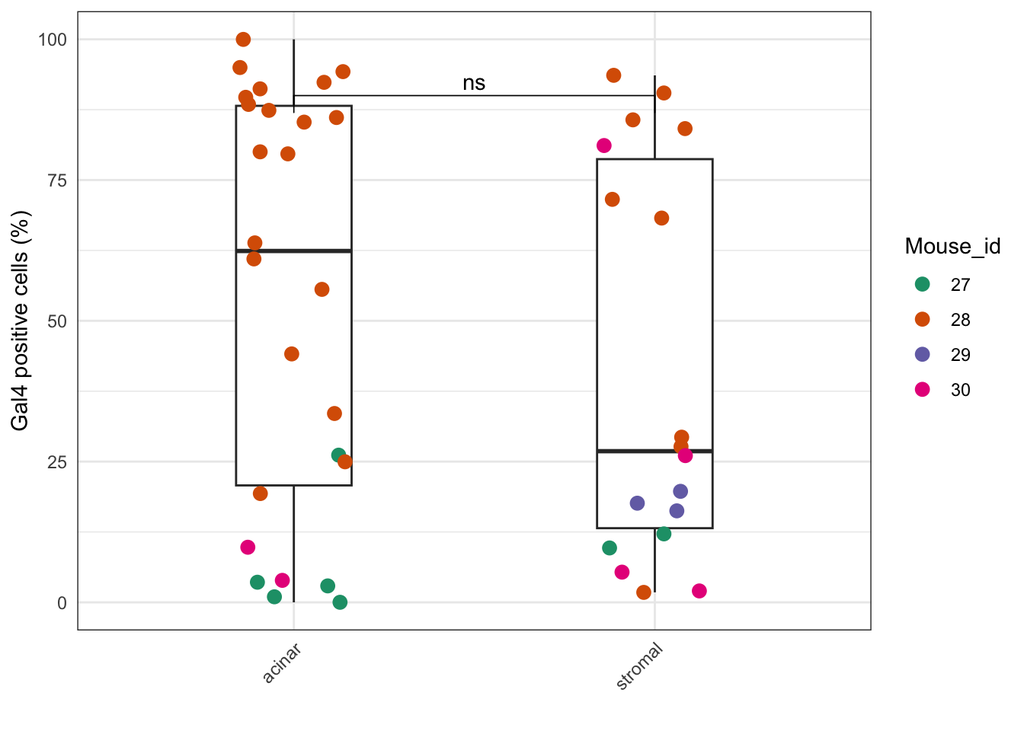

```r
# plot
box_Gal4 <- Gal4_Rsummary%>%
  ggplot(aes(x = invasion_type, y = Gal4pos_percent))+
  geom_boxplot(width = 0.32, outlier.shape = NA)+
  geom_jitter(aes(color = Mouse_id), alpha = 1, position=position_jitter(0.15), size = 2.8, seed = 1.5)+
  scale_color_brewer(palette = 'Dark2')+
          labs(x = '', y = 'Gal4 positive cells (%)')+
  theme_bw()+
  theme(legend.position = "right", axis.text.x = element_text(angle = 45, vjust = 1, hjust=1),
        axis.ticks = element_blank())+
    stat_pvalue_manual(res.wilG, label = 'p.adj.signif',
                     y.position = 90)+
  ylim(0,100)
box_Gal4
```

```r
gal4_split <- split(Gal4_Rsummary, f = Gal4_Rsummary$Mouse_id)

lapply(gal4_split, function (a) {
  b <- split(a, f = a$Image_id)
  lapply(b, function(c) {
    unique(c$Parent)
  })
}
)
```

```
## $`27`
## $`27`$GV_27_LobuleA
## [1] "Annotation (acinar_invasion_1)"  "Annotation (acinar_invasion_2)"
## [3] "Annotation (acinar_invasion_3)"  "Annotation (acinar_invasion_4)"
## [5] "Annotation (acinar_invasion_5)"  "Annotation (stromal_invasion_1)"
## [7] "Annotation (stromal_invasion_2)"
##
##
## $`28`
## $`28`$GV_28_LobuleA
## [1] "Annotation (acinar_invasion_1)"
##
## $`28`$GV_28_LobuleC
##  [1] "Annotation (acinar_invasion_1)"    "Annotation (acinar_invasion_10)"
##  [3] "Annotation (acinar_invasion_11)"   "Annotation (acinar_invasion_12)"
##  [5] "Annotation (acinar_invasion_13)"   "Annotation (acinar_invasion_14)"
##  [7] "Annotation (acinar_invasion_15)"   "Annotation (acinar_invasion_16)"
##  [9] "Annotation (acinar_invasion_17)"   "Annotation (acinar_invasion_18)"
## [11] "Annotation (acinar_invasion_2)"    "Annotation (acinar_invasion_3)"
## [13] "Annotation (acinar_invasion_4)"    "Annotation (acinar_invasion_5)"
## [15] "Annotation (acinar_invasion_6)"    "Annotation (acinar_invasion_7)"
## [17] "Annotation (acinar_invasion_8)"    "Annotation (acinar_invasion_9)"
## [19] "Annotation (stromal_invasion_1_A)" "Annotation (stromal_invasion_1)"
## [21] "Annotation (stromal_invasion_2_A)" "Annotation (stromal_invasion_2)"
## [23] "Annotation (stromal_invasion_3)"   "Annotation (stromal_invasion_4)"
## [25] "Annotation (stromal_invasion_6)"   "Annotation (stromal_invasion_7)"
## [27] "Annotation (stromal_invasion_8)"
##
##
## $`29`
## $`29`$GV_29_StromaA
## [1] "Annotation (stromal_invasion_1)" "Annotation (stromal_invasion_2)"
## [3] "Annotation (stromal_invasion_3)"
##
##
## $`30`
## $`30`$GV_30_LobuleA
## [1] "Annotation (acinar_invasion_1)"  "Annotation (acinar_invasion_3)"
## [3] "Annotation (stromal_invasion_1)" "Annotation (stromal_invasion_2)"
## [5] "Annotation (stromal_invasion_3)" "Annotation (stromal_invasion_4)"
```

# Results of the GATA6 quantification

Compared to the HMGA2 quantification, two ROIs could not be identified. Level differences in the sections rendered no tumor in these two regions, which is the same situation as the Gal4 quantification above.

## Data modification

```r
# Subset the data to only relevant information

GATA6.posdata <- og.data[og.data$Classification =="GATA6: Positive", ]
GATA6.negdata <- og.data[og.data$Classification =="GATA6: Negative", ]
GATA6.data <- rbind(GATA6.posdata, GATA6.negdata) # these are now all cells that are either GATA6+ or GATA6- cells, n = 8 141 cells.
dim(GATA6.data)
```

[1] 8141 3

```r
colnames(GATA6.data) <- c('Image', 'GATA6_status', 'Parent')
GATA6.data$Image_id <- gsub("\\..*","",GATA6.data$Image)

GATA6.data$Mouse_id <- gsub("HG_","",GATA6.data$Image)
GATA6.data$Mouse_id <- gsub("_.*","",GATA6.data$Mouse_id)
unique(GATA6.data$Mouse_id) # only case number left
```

[1] “30” “28” “27” “29”

```r
GATA6.data$GATA6_status <- gsub("GATA6: ","",GATA6.data$GATA6_status)
unique(GATA6.data$GATA6_status) # only status information left
```

[1] “Positive” “Negative”

```r
#create a new column to have plain info on the ROI (stroma/acinar)
GATA6.data$invasion_type <- gsub("_i.*","",GATA6.data$Parent)
GATA6.data$invasion_type <- gsub("Annotation \\(","",GATA6.data$invasion_type)
unique(GATA6.data$invasion_type)
```

[1] “acinar” “stromal”

```r
# convertion & new columns look as they should
knitr::kable(head(GATA6.data))
```

|  | Image | GATA6_status | Parent | Image_id | Mouse_id | invasion_type |
| --- | --- | --- | --- | --- | --- | --- |
| 12999 | HG_30_LobuleA | Positive | Annotation (acinar_invasion_1) | HG_30_LobuleA | 30 | acinar |
| 13000 | HG_30_LobuleA | Positive | Annotation (acinar_invasion_1) | HG_30_LobuleA | 30 | acinar |
| 13001 | HG_30_LobuleA | Positive | Annotation (acinar_invasion_1) | HG_30_LobuleA | 30 | acinar |
| 13002 | HG_30_LobuleA | Positive | Annotation (acinar_invasion_1) | HG_30_LobuleA | 30 | acinar |
| 13003 | HG_30_LobuleA | Positive | Annotation (acinar_invasion_1) | HG_30_LobuleA | 30 | acinar |
| 13004 | HG_30_LobuleA | Positive | Annotation (acinar_invasion_1) | HG_30_LobuleA | 30 | acinar |

## Details

### Summary/ROI

```r
GATA6_summary <- GATA6.data %>%
  select(Image_id, Mouse_id, invasion_type, Parent)%>%
  group_by(Image_id, Mouse_id, invasion_type, Parent)%>%
  dplyr::summarise(Detections = n())
```

```
## You can override using the `.groups` argument.
```

```r
GATA6_pos <- GATA6.data %>%
  filter(GATA6_status == 'Positive')%>%
  select(Image_id, Mouse_id, invasion_type, Parent)%>%
  group_by(Image_id, Mouse_id, invasion_type, Parent)%>%
  dplyr::summarise(GATA6pos = n())
```

```
## You can override using the `.groups` argument.
```

```r
GATA6_Rsummary <- merge(x = GATA6_summary, y = GATA6_pos, id = c('Mouse_id', 'Parent'), all = TRUE)
GATA6_Rsummary[is.na(GATA6_Rsummary)] <- 0

GATA6_Rsummary <- GATA6_Rsummary%>%
  mutate(GATA6pos_percent = GATA6pos/Detections*100)%>%
  data.frame()

knitr::kable(GATA6_Rsummary)
```

| Image_id | Mouse_id | invasion_type | Parent | Detections | GATA6pos | GATA6pos_percent |
| --- | --- | --- | --- | --- | --- | --- |
| HG_27_LobuleA | 27 | acinar | Annotation (acinar_invasion_1) | 73 | 55 | 75.34247 |
| HG_27_LobuleA | 27 | acinar | Annotation (acinar_invasion_2) | 88 | 43 | 48.86364 |
| HG_27_LobuleA | 27 | acinar | Annotation (acinar_invasion_3) | 24 | 14 | 58.33333 |
| HG_27_LobuleA | 27 | acinar | Annotation (acinar_invasion_4) | 64 | 22 | 34.37500 |
| HG_27_LobuleA | 27 | acinar | Annotation (acinar_invasion_5) | 74 | 19 | 25.67568 |
| HG_27_LobuleA | 27 | stromal | Annotation (stromal_invasion_1) | 234 | 178 | 76.06838 |
| HG_27_LobuleA | 27 | stromal | Annotation (stromal_invasion_2) | 342 | 264 | 77.19298 |
| HG_28_LobuleA | 28 | acinar | Annotation (acinar_invasion_1) | 86 | 29 | 33.72093 |
| HG_28_LobuleC | 28 | acinar | Annotation (acinar_invasion_1) | 248 | 70 | 28.22581 |
| HG_28_LobuleC | 28 | acinar | Annotation (acinar_invasion_10) | 37 | 31 | 83.78378 |
| HG_28_LobuleC | 28 | acinar | Annotation (acinar_invasion_11) | 173 | 91 | 52.60116 |
| HG_28_LobuleC | 28 | acinar | Annotation (acinar_invasion_12) | 30 | 26 | 86.66667 |
| HG_28_LobuleC | 28 | acinar | Annotation (acinar_invasion_13) | 40 | 7 | 17.50000 |
| HG_28_LobuleC | 28 | acinar | Annotation (acinar_invasion_14) | 66 | 47 | 71.21212 |
| HG_28_LobuleC | 28 | acinar | Annotation (acinar_invasion_15) | 97 | 52 | 53.60825 |
| HG_28_LobuleC | 28 | acinar | Annotation (acinar_invasion_16) | 104 | 89 | 85.57692 |
| HG_28_LobuleC | 28 | acinar | Annotation (acinar_invasion_17) | 178 | 129 | 72.47191 |
| HG_28_LobuleC | 28 | acinar | Annotation (acinar_invasion_18) | 95 | 73 | 76.84211 |
| HG_28_LobuleC | 28 | acinar | Annotation (acinar_invasion_2) | 50 | 41 | 82.00000 |
| HG_28_LobuleC | 28 | acinar | Annotation (acinar_invasion_3) | 82 | 55 | 67.07317 |
| HG_28_LobuleC | 28 | acinar | Annotation (acinar_invasion_4) | 411 | 179 | 43.55231 |
| HG_28_LobuleC | 28 | acinar | Annotation (acinar_invasion_5) | 121 | 93 | 76.85950 |
| HG_28_LobuleC | 28 | acinar | Annotation (acinar_invasion_6) | 98 | 87 | 88.77551 |
| HG_28_LobuleC | 28 | acinar | Annotation (acinar_invasion_7) | 46 | 42 | 91.30435 |
| HG_28_LobuleC | 28 | acinar | Annotation (acinar_invasion_8) | 121 | 103 | 85.12397 |
| HG_28_LobuleC | 28 | acinar | Annotation (acinar_invasion_9) | 167 | 128 | 76.64671 |
| HG_28_LobuleC | 28 | stromal | Annotation (stromal_invasion_1_A) | 277 | 212 | 76.53430 |
| HG_28_LobuleC | 28 | stromal | Annotation (stromal_invasion_1) | 48 | 19 | 39.58333 |
| HG_28_LobuleC | 28 | stromal | Annotation (stromal_invasion_2_A) | 249 | 173 | 69.47791 |
| HG_28_LobuleC | 28 | stromal | Annotation (stromal_invasion_2) | 93 | 26 | 27.95699 |
| HG_28_LobuleC | 28 | stromal | Annotation (stromal_invasion_3) | 169 | 72 | 42.60355 |
| HG_28_LobuleC | 28 | stromal | Annotation (stromal_invasion_4) | 205 | 180 | 87.80488 |
| HG_28_LobuleC | 28 | stromal | Annotation (stromal_invasion_6) | 292 | 212 | 72.60274 |
| HG_28_LobuleC | 28 | stromal | Annotation (stromal_invasion_7) | 145 | 137 | 94.48276 |
| HG_28_LobuleC | 28 | stromal | Annotation (stromal_invasion_8) | 320 | 228 | 71.25000 |
| HG_29_StromaA | 29 | stromal | Annotation (stromal_invasion_1) | 463 | 402 | 86.82505 |
| HG_29_StromaA | 29 | stromal | Annotation (stromal_invasion_2) | 1298 | 914 | 70.41602 |
| HG_29_StromaA | 29 | stromal | Annotation (stromal_invasion_3) | 522 | 466 | 89.27203 |
| HG_30_LobuleA | 30 | acinar | Annotation (acinar_invasion_1) | 145 | 126 | 86.89655 |
| HG_30_LobuleA | 30 | acinar | Annotation (acinar_invasion_3) | 95 | 68 | 71.57895 |
| HG_30_LobuleA | 30 | stromal | Annotation (stromal_invasion_1) | 236 | 184 | 77.96610 |
| HG_30_LobuleA | 30 | stromal | Annotation (stromal_invasion_2) | 191 | 178 | 93.19372 |
| HG_30_LobuleA | 30 | stromal | Annotation (stromal_invasion_3) | 110 | 98 | 89.09091 |
| HG_30_LobuleA | 30 | stromal | Annotation (stromal_invasion_4) | 134 | 106 | 79.10448 |

### Summary/mouse_id

```r
ROIs <- GATA6_Rsummary %>%
  select(Mouse_id, invasion_type)%>%
  group_by(Mouse_id, invasion_type)%>%
  dplyr::summarise(ROIs = n())
GATA6_Msummary <- GATA6.data %>%
  select(Mouse_id, invasion_type)%>%
  group_by(Mouse_id, invasion_type)%>%
  dplyr::summarise(Detections = n())
GATA6_pos <- GATA6.data %>%
  filter(GATA6_status == 'Positive')%>%
  select(Mouse_id, invasion_type)%>%
  group_by(Mouse_id, invasion_type)%>%
  dplyr::summarise(GATA6pos = n())
GATA6_Msummary <- merge(x = GATA6_Msummary, y = GATA6_pos, id = c('Mouse_id'))
GATA6_Msummary <- merge(x = GATA6_Msummary, y = ROIs, id = c('Mouse_id', 'invasion_type'))
GATA6_Msummary <- GATA6_Msummary%>%
  mutate(GATA6pos_percent = GATA6pos/Detections*100)%>%
  data.frame()

knitr::kable(GATA6_Msummary)
```

| Mouse_id | invasion_type | Detections | GATA6pos | ROIs | GATA6pos_percent |
| --- | --- | --- | --- | --- | --- |
| 27 | acinar | 323 | 153 | 5 | 47.36842 |
| 27 | stromal | 576 | 442 | 2 | 76.73611 |
| 28 | acinar | 2250 | 1372 | 19 | 60.97778 |
| 28 | stromal | 1798 | 1259 | 9 | 70.02225 |
| 29 | stromal | 2283 | 1782 | 3 | 78.05519 |
| 30 | acinar | 240 | 194 | 2 | 80.83333 |
| 30 | stromal | 671 | 566 | 4 | 84.35171 |

## Statistical testing

```r
# Wilcox test (non-paired)
res.wilGATA6 <-  GATA6_Rsummary%>%
  wilcox_test(GATA6pos_percent~invasion_type)%>%
  adjust_pvalue(method = 'BH')%>%
  add_significance()
res.wilGATA6 <- res.wilGATA6 %>% add_xy_position(x = 'invasion_type')
res.wilGATA6
```

```
## # A tibble: 1 × 13
##   .y.    group1 group2    n1    n2 statistic     p p.adj p.adj.signif y.position
##   <chr>  <chr>  <chr>  <int> <int>     <dbl> <dbl> <dbl> <chr>             <dbl>
## 1 GATA6… acinar strom…    26    18       175 0.164 0.164 ns                 94.9
## # ℹ 3 more variables: groups <named list>, xmin <dbl>, xmax <dbl>
```

## Boxplot of GATA6

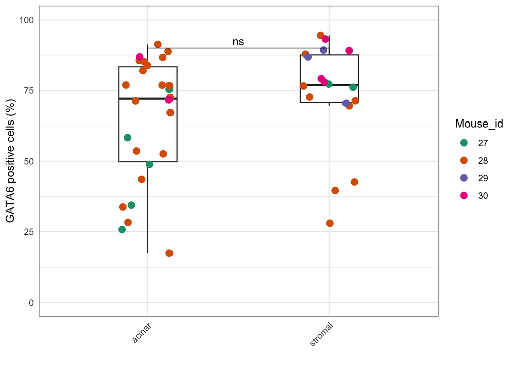

```r
# plot
box_GATA6 <- GATA6_Rsummary %>%
  ggplot(aes(x = invasion_type, y = GATA6pos_percent))+
  geom_boxplot(width = 0.32, outlier.shape = NA)+
  geom_jitter(aes(color = Mouse_id), alpha = 1, position=position_jitter(0.15), size = 2.8, seed = 1.5)+
  scale_color_brewer(palette = 'Dark2')+
          labs(x = '', y = 'GATA6 positive cells (%)')+
  theme_bw()+
  theme(legend.position = "right", axis.text.x = element_text(angle = 45, vjust = 1, hjust=1),
        axis.ticks = element_blank())+
    stat_pvalue_manual(res.wilGATA6, label = 'p.adj.signif',
                     y.position = 90)+
  ylim(0,100)
box_GATA6
```

Merging marker expression depending on the ROI identity

```r
#HMGA2
HMGA2_m <- HMGA2_Rsummary

HMGA2_m$ROI_ID <- gsub(".*_invasion_","",HMGA2_m$Parent)
HMGA2_m$ROI_ID <- gsub("\\)","",HMGA2_m$ROI_ID)
unique(HMGA2_m$ROI_ID)
```

```
##  [1] "1"   "3"   "2"   "4"   "5"   "1_A" "2_A" "10"  "11"  "12"  "13"  "14"
## [13] "15"  "16"  "17"  "18"  "6"   "7"   "8"   "9"
```

```r
HMGA2_m$Image <- HMGA2_m$Image_id
HMGA2_m$Image <- gsub(".*_.*_", "", HMGA2_m$Image)

HMGA2_m$Group <- factor(nrow(HMGA2_m))
HMGA2_m$Group <- paste(HMGA2_m$Mouse_id, HMGA2_m$invasion_type, HMGA2_m$Image, HMGA2_m$ROI_ID, sep = "_")

#Gal4
Gal4_m <- Gal4_Rsummary

Gal4_m$ROI_ID <- gsub(".*_invasion_","",Gal4_m$Parent)
Gal4_m$ROI_ID <- gsub("\\)","",Gal4_m$ROI_ID)
unique(Gal4_m$ROI_ID)
```

```
##  [1] "1"   "2"   "3"   "4"   "5"   "10"  "11"  "12"  "13"  "14"  "15"  "16"
## [13] "17"  "18"  "6"   "7"   "8"   "9"   "1_A" "2_A"
```

```r
Gal4_m$Image <- Gal4_m$Image_id
Gal4_m$Image <- gsub(".*_.*_", "", Gal4_m$Image)

Gal4_m$Group <- factor(nrow(Gal4_m))
Gal4_m$Group <- paste(Gal4_m$Mouse_id, Gal4_m$invasion_type, Gal4_m$Image, Gal4_m$ROI_ID, sep = "_")

#align the rois that were set on the images LobuleC in Gal4 quant, but LobuleB in HMGA2 quant:
#28_stromal_LobuleB_1_A = 28_stromal_LobuleC_1_A  and #28_stromal_LobuleB_2_A = 28_stromal_LobuleC_2_A
#the group column of the gal4 dataset will be adjusted to that.

Gal4_m <- Gal4_m %>% mutate(Group = ifelse(grepl("28_stromal_LobuleC_1_A", .$Group), '28_stromal_LobuleB_1_A', .$Group))
Gal4_m <- Gal4_m %>% mutate(Group = ifelse(grepl("28_stromal_LobuleC_2_A", .$Group), '28_stromal_LobuleB_2_A', .$Group))

Gal4_m <- Gal4_m[, -c(1, 4:6, 8, 9)]
HMGA2_m <- HMGA2_m[, -c(1, 4:6, 8, 9)]

mHMGA2_Gal4 <- merge(x = Gal4_m, y = HMGA2_m, id = c('Mouse_id', 'invasion_type', 'Group'), all = TRUE)
```

```r
mheatmat <- mHMGA2_Gal4
rownames(mheatmat) <- mheatmat$Group
meta_mheatmap <- mheatmat #for metadata
meta_mheatmap <- meta_mheatmap[, -c(3:5)]
meta_mheatmap <- meta_mheatmap[-c(27, 28),]

meta_mheatmap$Mouse_id <- paste("m", meta_mheatmap$Mouse_id, sep = "")
mheatmat <- mheatmat[, -c(1:3)]
mheatmat <- mheatmat[-c(27, 28), ]

meta_colors <- list(Mouse_id=c(m27="#fbb4ae", m28="#b3cde3", m29="#ccebc5", m30="#decbe4"),
                    invasion_type=c(acinar = "#66c2a5", stromal = "#fc8d62"))
```

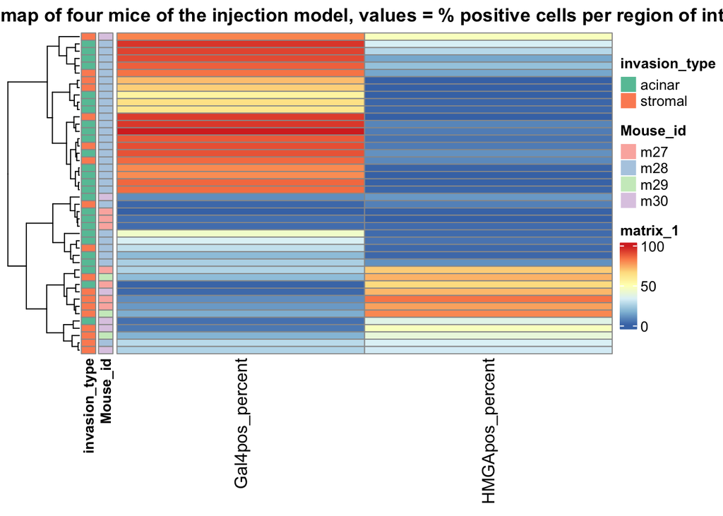

```r
pheatmap(mheatmat, fontsize_col = 12, annotation_row = meta_mheatmap, annotation_colors = meta_colors, show_colnames = TRUE, show_rownames = FALSE, main = "Heatmap of four mice of the injection model, values = % positive cells per region of interest", cluster_cols = FALSE, cluster_rows = TRUE)
```

```r
pcamat <- mHMGA2_Gal4[, -3]
pcamat <- pcamat[-c(27, 28), ]
```

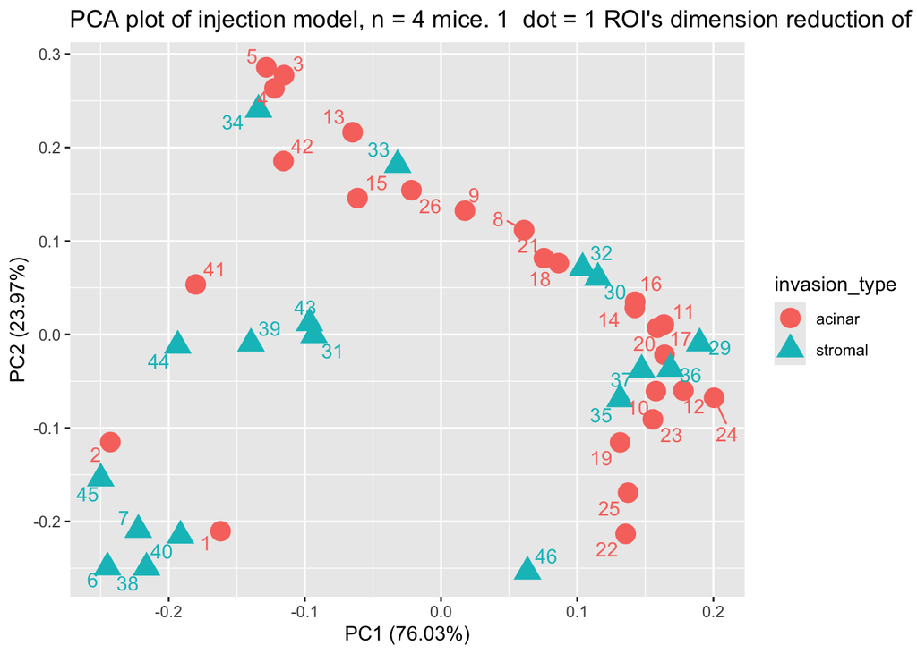

```r
PCA_all <- autoplot(prcomp(pcamat[3:4]), data = pcamat, colour = 'invasion_type', shape = 'invasion_type', size = 5, label = TRUE, repel = TRUE, label.repel = TRUE, main = "PCA plot of injection model, n = 4 mice. 1  dot = 1 ROI's dimension reduction of two stains")
PCA_all
```

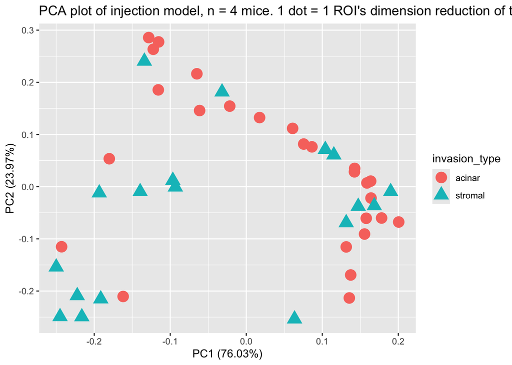

```r
PCA_all_nolabel <- autoplot(prcomp(pcamat[3:4]), data = pcamat, colour = 'invasion_type', shape = 'invasion_type', size = 5, label = FALSE, repel = TRUE, main = "PCA plot of injection model, n = 4 mice. 1 dot = 1 ROI's dimension reduction of two stains")
PCA_all_nolabel
```

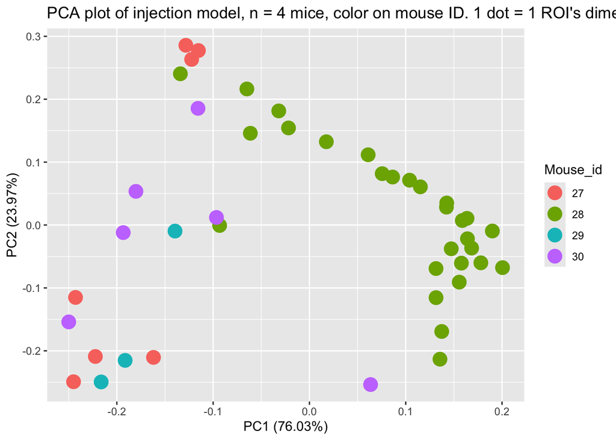

```r
PCA_all_id <- autoplot(prcomp(pcamat[3:4]), data = pcamat, colour = 'Mouse_id', size = 5, label = FALSE, repel = TRUE, main = "PCA plot of injection model, n = 4 mice, color on mouse ID. 1 dot = 1 ROI's dimension reduction of two stains")
PCA_all_id
```

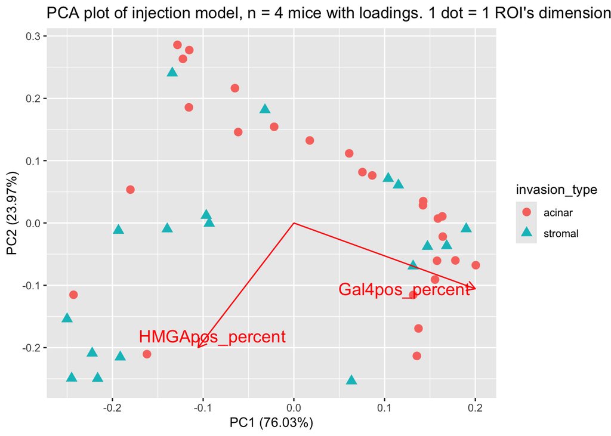

```r
PCA_all_loadings <- autoplot(prcomp(pcamat[3:4]), loadings = TRUE, loadings.label = TRUE, loadings.label.repel = TRUE, loadings.label.size  = 5, data = pcamat, colour = 'invasion_type', shape = 'invasion_type', size = 3, label = FALSE, repel = TRUE, main = "PCA plot of injection model, n = 4 mice with loadings. 1 dot = 1 ROI's dimension reduction of two stains")

PCA_all_loadings
```

```r
summary(prcomp(pcamat[3:4]))
```

```
## Importance of components:
##                            PC1     PC2
## Standard deviation     39.3145 22.0744
## Proportion of Variance  0.7603  0.2397
## Cumulative Proportion   0.7603  1.0000
```

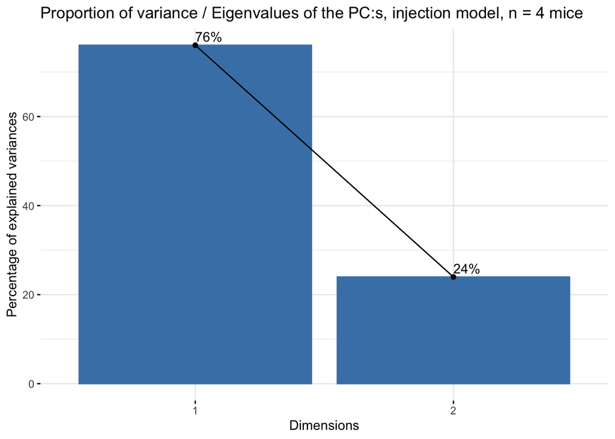

```r
fviz_screeplot(prcomp(pcamat[3:4]), addlabels = TRUE, main = "Proportion of variance / Eigenvalues of the PC:s, injection model, n = 4 mice")
```

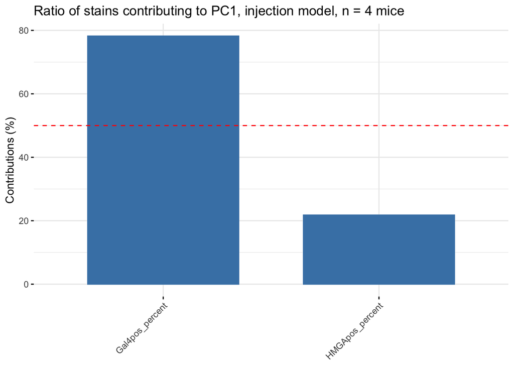

```r
# Add in the fviz_contrib
fviz_contrib(prcomp(pcamat[3:4]), choice = "var", axes = 1, title = "Ratio of stains contributing to PC1, injection model, n = 4 mice")
```

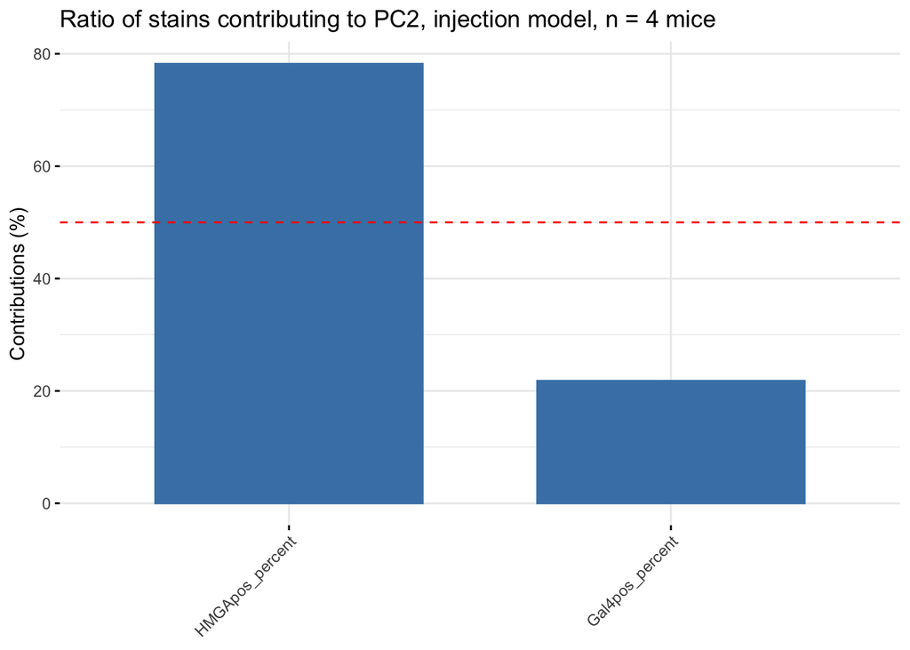

```r
fviz_contrib(prcomp(pcamat[3:4]), choice = "var", axes = 2, title = "Ratio of stains contributing to PC2, injection model, n = 4 mice")
```

```r
mall_cor <- mHMGA2_Gal4
rownames(mall_cor) <- mall_cor$Group
mall_cor <- mall_cor[, -c(1:3)]
mall_cor <- mall_cor[ -c(27:28),]


cor_all <- cor(mall_cor)
testRes_all= cor.mtest(mall_cor, conf.level = 0.95)

cor_p_all<- testRes_all$p
cor_p_all
```

```
##                 Gal4pos_percent HMGApos_percent
## Gal4pos_percent     0.000000000     0.002197816
## HMGApos_percent     0.002197816     0.000000000
```

[figure not shown]

```r
col_fun<- circlize::colorRamp2(c(-1, 0, 1), c("#008837", "#f7f7f7", "#7b3294"))

cell_fun = function(j, i, x, y, w, h, fill){
  if(as.numeric(x) <= 1 - as.numeric(y) + 1e-6) {
    grid.rect(x, y, w, h, gp = gpar(fill = fill, col = fill))
  }

  if (cor_p_all[i, j]  < 0.01 & as.numeric(x) <= 1 - as.numeric(y) + 1e-6){
    grid.text(paste0(sprintf("%.2f", cor_all[i, j]),"**"), x, y, gp = gpar(fontsize = 10))
  } else if (cor_p_all[i, j]  <= 0.05 & as.numeric(x) <= 1 - as.numeric(y) + 1e-6){
    grid.text(paste0(sprintf("%.2f", cor_all[i, j]),"*"), x, y, gp = gpar(fontsize = 10))
  }
}

correlation_all <- ComplexHeatmap::Heatmap(cor_all,
                                          rect_gp = gpar(type = "none"),
                                          column_dend_side = "bottom",
                                          column_title = "Correlation of stains of the injection model. Unmatched ROIs are excluded",
                                          column_title_gp = gpar(fontsize = 12, fontface = "bold"),
                                          name = "Spearman's rank correlation coefficient", col = col_fun,
                                          cell_fun = cell_fun,
                                          cluster_rows = TRUE, cluster_columns = TRUE,
                                          row_names_side = "left")

lgd_list = list(
  Legend( labels = c("<0.01", "<0.05"), title = "p-value",
          graphics = list(
            function(x, y, w, h) grid.text("**", x = x, y = y,
                                           gp = gpar(fill = "black")),
            function(x, y, w, h) grid.text("*", x = x, y = y,
                                           gp = gpar(fill = "black")))
  ))

correlation_all
```

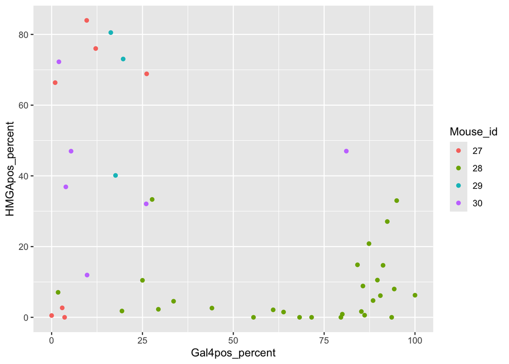

```r
ggplot(mHMGA2_Gal4, aes(x = Gal4pos_percent, y = HMGApos_percent, colour = Mouse_id)) +
  geom_point()
```

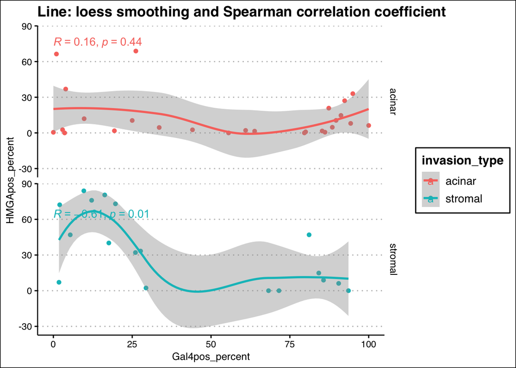

```r
ggplot(mHMGA2_Gal4, aes(x = Gal4pos_percent, y = HMGApos_percent, colour = invasion_type)) +
  geom_point() +
  geom_smooth(method = "loess") +
  facet_grid(invasion_type ~ .) +
  labs(title = "Line: loess smoothing and Spearman correlation coefficient")  +
  stat_cor(p.accuracy = 0.005, r.accuracy = 0.01, method = "spearman") +
  theme_clean()
```

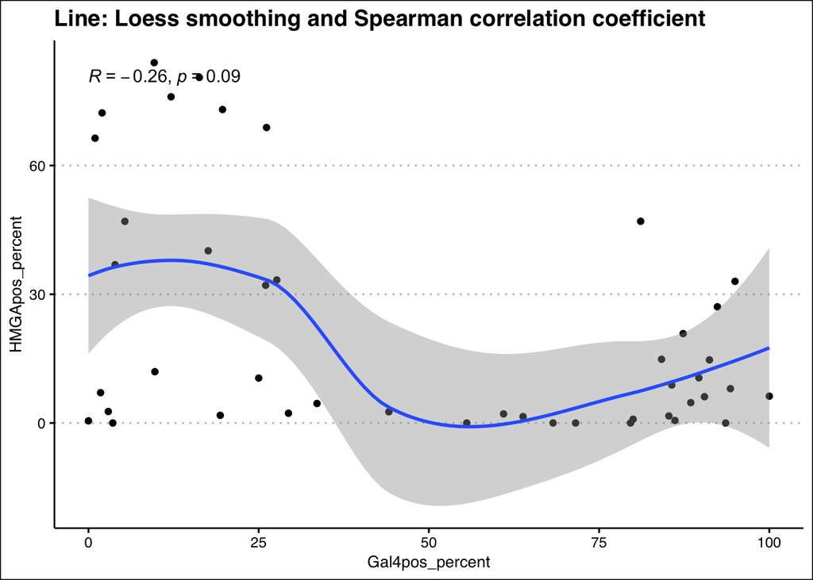

```r
ggplot(mHMGA2_Gal4, aes(x = Gal4pos_percent, y = HMGApos_percent)) +
  geom_point() +
  geom_smooth(method = "loess")+
  stat_cor(p.accuracy = 0.005, r.accuracy = 0.01, method = "spearman") +
  labs(title = "Line: Loess smoothing and Spearman correlation coefficient") +
  theme_clean()
```

```r
cor(mHMGA2_Gal4$Gal4pos_percent, mHMGA2_Gal4$HMGApos_percent, use = "pairwise.complete.obs")
```

```
## [1] -0.4496448
```

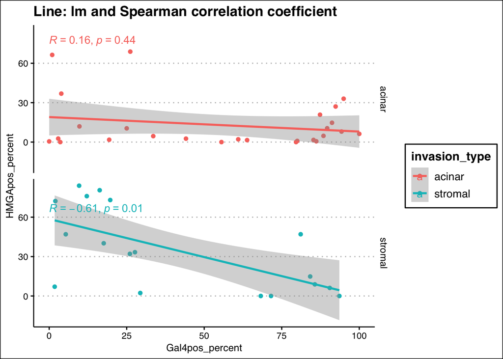

```r
# lm fit
ggplot(mHMGA2_Gal4, aes(x = Gal4pos_percent, y = HMGApos_percent, colour = invasion_type)) +
  geom_point() +
  geom_smooth(method = "lm") +
  facet_grid(invasion_type ~ .) +
  labs(title = "Line: lm and Spearman correlation coefficient")  +
  stat_cor(p.accuracy = 0.005, r.accuracy = 0.01, method = "spearman") +
  theme_clean()
```

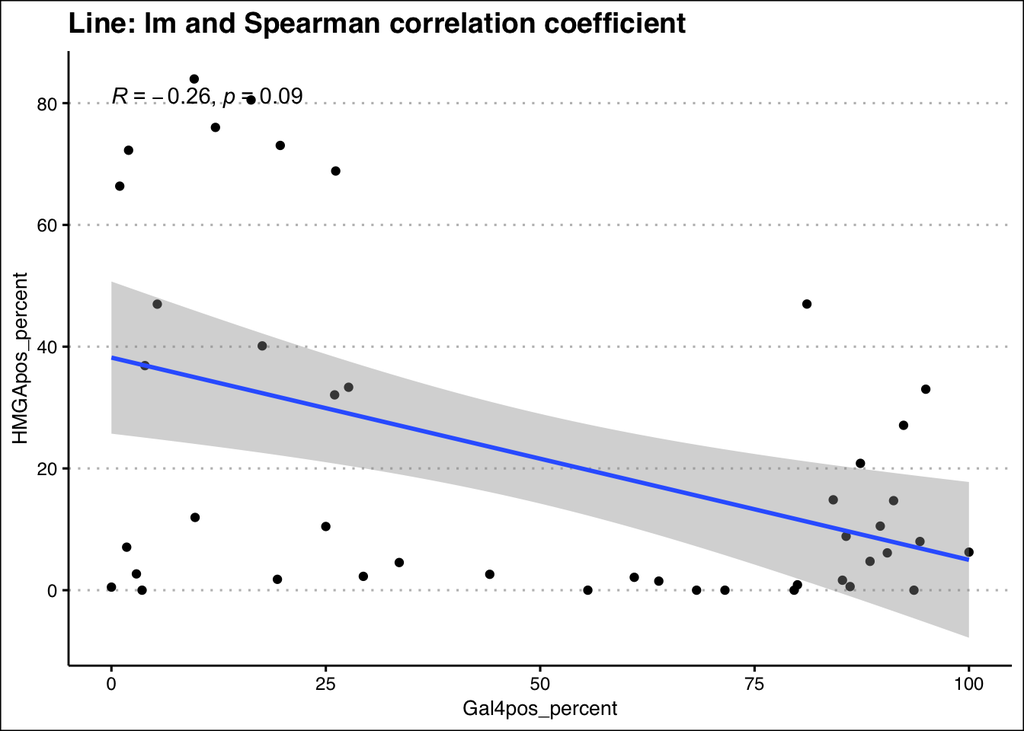

```r
ggplot(mHMGA2_Gal4, aes(x = Gal4pos_percent, y = HMGApos_percent)) +
  geom_point() +
  geom_smooth(method = "lm")+
  stat_cor(p.accuracy = 0.005, r.accuracy = 0.01, method = "spearman") +
  labs(title = "Line: lm and Spearman correlation coefficient") +
  theme_clean()
```

```r
sm_HMGA2_GATA6 <- split(mHMGA2_Gal4, f = mHMGA2_Gal4$invasion_type)


Gal4mean <- lapply(sm_HMGA2_GATA6, function (a) {
 mean(a$Gal4pos_percent, na.rm = TRUE)
}
)

HMGA2mean <- lapply(sm_HMGA2_GATA6, function (a) {
 mean(a$HMGApos_percent, na.rm = TRUE)
}
)
Gal4mean
```

```
## $acinar
## [1] 54.57485
##
## $stromal
## [1] 41.23989
```

```r
HMGA2mean
```

```
## $acinar
## [1] 14.3187
##
## $stromal
## [1] 32.90322
```

```r
Gal4median <- lapply(sm_HMGA2_GATA6, function (a) {
 median(a$Gal4pos_percent, na.rm = TRUE)
}
)
HMGA2median <- lapply(sm_HMGA2_GATA6, function (a) {
 median(a$HMGApos_percent, na.rm = TRUE)
}
)
Gal4median
```

```
## $acinar
## [1] 62.39959
##
## $stromal
## [1] 26.84349
```

```r
HMGA2median
```

```
## $acinar
## [1] 4.739336
##
## $stromal
## [1] 32.08191
```

Boxplots, paired on the roi id

```r
order_HGal_melt_og <- mHMGA2_Gal4
colnames(order_HGal_melt_og) [4] <- "Gal4"
colnames(order_HGal_melt_og) [5] <- "HMGA2"

#Two rois could not be matched overlappingly, exclude those:
order_HGal_melt_og <- order_HGal_melt_og[-c(27, 28),]
order_HGal_melt <- melt(order_HGal_melt_og, id.vars = c("Mouse_id", "invasion_type", "Group"), value.name = "Fraction", variable.name = "Marker")
order_HGal <- order_HGal_melt[order(order_HGal_melt[,3] ),] # Ordering by the third column 'Group' = specific ROI ID
head(order_HGal)
```

```
##    Mouse_id invasion_type               Group Marker   Fraction
## 1        27        acinar 27_acinar_LobuleA_1   Gal4 26.1538462
## 45       27        acinar 27_acinar_LobuleA_1  HMGA2 68.8524590
## 2        27        acinar 27_acinar_LobuleA_2   Gal4  0.9708738
## 46       27        acinar 27_acinar_LobuleA_2  HMGA2 66.3636364
## 3        27        acinar 27_acinar_LobuleA_3   Gal4  3.5714286
## 47       27        acinar 27_acinar_LobuleA_3  HMGA2  0.0000000
```

```r
#stat tests. Comparison: are HMGA2 and Gal4 differentially expressed in (the same) ROI?
wilcox_pair<- order_HGal %>%
  wilcox_test(Fraction ~ Marker, paired = TRUE) %>%
  adjust_pvalue(method = "BH") %>%
  add_significance("p.adj")

wilcox_pair <- wilcox_pair %>% add_xy_position()
wilcox_pair
```

```
## # A tibble: 1 × 13
##   .y.      group1 group2    n1    n2 statistic      p  p.adj p.adj.signif
##   <chr>    <chr>  <chr>  <int> <int>     <dbl>  <dbl>  <dbl> <chr>
## 1 Fraction Gal4   HMGA2     44    44       758 0.0017 0.0017 **
## # ℹ 4 more variables: y.position <dbl>, groups <named list>, xmin <dbl>,
## #   xmax <dbl>
```

```r
# Comparison: are HMGA2 and Gal4 differentially expressed in (the same) ROI, separated on the tissue location?
wilcox_pair_g <- order_HGal %>%
  group_by(invasion_type) %>%
  wilcox_test(Fraction ~ Marker, paired = TRUE) %>%
  adjust_pvalue(method = "BH") %>%
  add_significance("p.adj")

wilcox_pair_g <- wilcox_pair_g %>% add_xy_position()
wilcox_pair_g [11] <- 110
wilcox_pair_g
```

```
## # A tibble: 2 × 14
##   invasion_type .y.      group1 group2    n1    n2 statistic        p    p.adj
##   <chr>         <chr>    <chr>  <chr>  <int> <int>     <dbl>    <dbl>    <dbl>
## 1 acinar        Fraction Gal4   HMGA2     26    26       312 0.000217 0.000434
## 2 stromal       Fraction Gal4   HMGA2     18    18        99 0.58     0.58
## # ℹ 5 more variables: p.adj.signif <chr>, y.position <dbl>,
## #   groups <named list>, xmin <dbl>, xmax <dbl>
```

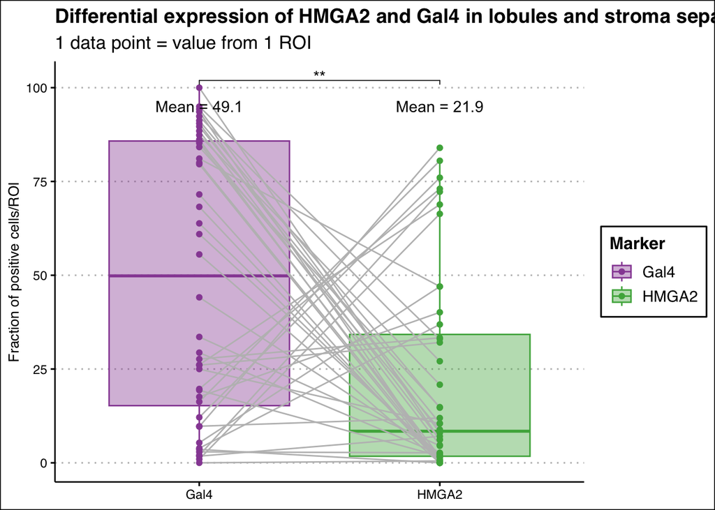

```r
# Boxplot
boxes_HGal <- ggplot(order_HGal, aes(x = Marker, y = Fraction)) +
  geom_boxplot(aes(color = Marker, fill = Marker), alpha = 0.4) +
  geom_line(aes(group = Group), colour = "grey") +
  geom_point(size = 1.5, aes(fill = Marker, color = Marker)) +
  xlab(NULL) + ylab("Fraction of positive cells/ROI") +
  stat_summary(fun.data = function(x) data.frame(y = 95, label = paste("Mean =",round(mean(x), digits = 1))), geom="text") +
  labs(title = "Differential expression of HMGA2 and Gal4 in lobules and stroma separately", subtitle = "1 data point = value from 1 ROI") +
  theme_clean() +
  scale_color_manual(values = c("#984ea3", "#4daf4a")) +
  scale_fill_manual(values = c("#984ea3", "#4daf4a"))

boxes_HGal_sign <- boxes_HGal + stat_pvalue_manual(label = "p.adj.signif",
                                                    wilcox_pair, tip.length = 0.01)
boxes_HGal_sign
```

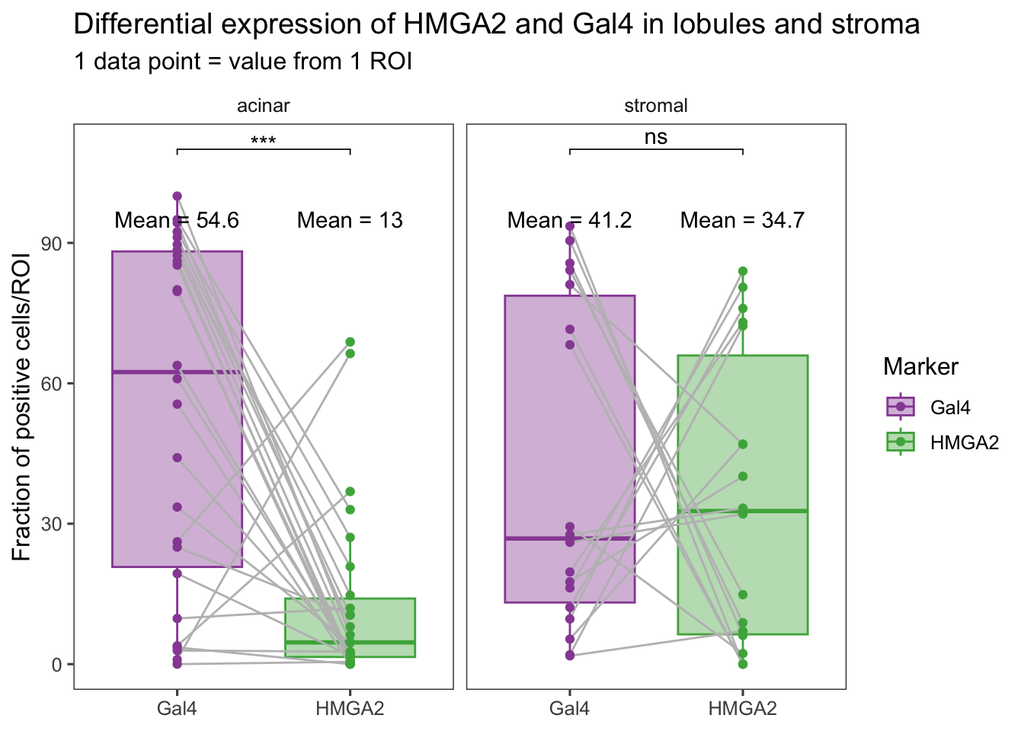

```r
boxes_HGal_g <- ggplot(order_HGal, aes(x = Marker, y = Fraction)) +
  geom_boxplot(aes(color = Marker, fill = Marker), alpha = 0.4) +
  geom_line(aes(group = Group), colour = "grey") +
  geom_point(size = 1.5, aes(fill = Marker, color = Marker)) +
  facet_wrap(invasion_type ~.) +
  xlab(NULL) + ylab("Fraction of positive cells/ROI") +
  stat_summary(fun.data = function(x) data.frame(y = 95, label = paste("Mean =",round(mean(x), digits = 1))), geom="text") +
  labs(title = "Differential expression of HMGA2 and Gal4 in lobules and stroma", subtitle = "1 data point = value from 1 ROI") +
  scale_color_manual(values = c("#984ea3", "#4daf4a")) +
  scale_fill_manual(values = c("#984ea3", "#4daf4a")) +
  theme_few()

boxes_HGal_g_sign <- boxes_HGal_g + stat_pvalue_manual(label = "p.adj.signif",
                                                    wilcox_pair_g, tip.length = 0.01)
boxes_HGal_g_sign
```

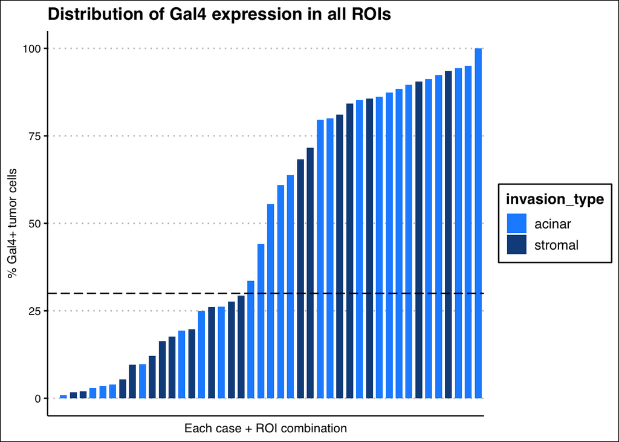

```r
distrib_Gal4 <-ggplot(order_HGal_melt_og, aes(x=fct_reorder(Group, Gal4), y=Gal4, fill = invasion_type)) +
  geom_col(width = 0.7) +
  labs(title = "Distribution of Gal4 expression in all ROIs") +
  theme_clean() +
  labs(x = "Each case + ROI combination", y = "% Gal4+ tumor cells") +
  theme(axis.text.x=element_blank(), axis.ticks.x=element_blank()) +
  scale_fill_manual(values = c("dodgerblue1", "dodgerblue4")) +
  geom_hline(yintercept = 30,linetype = "longdash")

distrib_Gal4
```

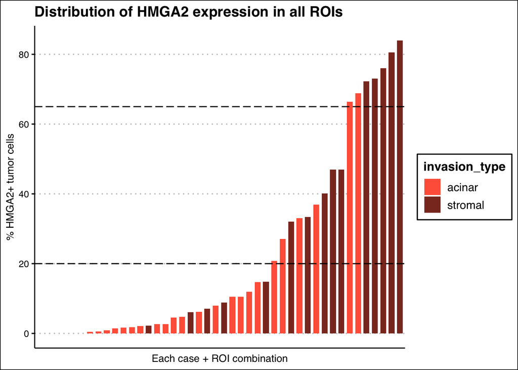

```r
distrib_HMGA2 <-ggplot(order_HGal_melt_og, aes(x=fct_reorder(Group, HMGA2), y=HMGA2, fill = invasion_type)) +
  geom_col(width = 0.7) +
  labs(title = "Distribution of HMGA2 expression in all ROIs") +
  theme_clean() +
  labs(x = "Each case + ROI combination", y = "% HMGA2+ tumor cells") +
  theme(axis.text.x=element_blank(), axis.ticks.x=element_blank()) +
  scale_fill_manual(values = c("tomato1", "tomato4"))+
  geom_hline(yintercept = 65,linetype = "longdash") +
  geom_hline(yintercept = 20,linetype = "longdash")
distrib_HMGA2
```

#Cutoffs to work with For HMGA2: High = >50% Medium: 20-50% Low: <20%

For Gal4: High: =>30% Low: <30%

Assign an overall subtype for each ROI, depending on the expression pattern och Galectin-4 and HMGA2

```r
subtypes <- order_HGal_melt_og
subtypes$Subtype <- factor(nrow(subtypes))
subtypes$Weight <- factor(nrow(subtypes))
subtypes$Subtype_group <- factor(nrow(subtypes))

subtypes <- subtypes %>% mutate(Subtype = ifelse(HMGA2 < 20 & Gal4 < 30, 'Hybrid', .$Subtype))
subtypes <- subtypes %>% mutate(Weight = ifelse(HMGA2 < 20 & Gal4 < 30, '1', .$Weight))
subtypes <- subtypes %>% mutate(Subtype_group = ifelse(HMGA2 < 20 & Gal4 < 30, 'Weak_hybrid', .$Subtype_group))


subtypes <- subtypes %>% mutate(Subtype = ifelse(HMGA2 < 20 & Gal4 > 30, 'Classical', .$Subtype))
subtypes <- subtypes %>% mutate(Weight = ifelse(HMGA2 < 20 & Gal4 > 30, '2', .$Weight))
subtypes <- subtypes %>% mutate(Subtype_group = ifelse(HMGA2 < 20 & Gal4 > 30, 'Strong_classical', .$Subtype_group))

subtypes <- subtypes %>% mutate(Subtype = ifelse(HMGA2 < 50 & HMGA2 > 20 & Gal4 < 30, 'Basal', .$Subtype))
subtypes <- subtypes %>% mutate(Weight = ifelse(HMGA2 < 50 & HMGA2 > 20 & Gal4 < 30, '1', .$Weight))
subtypes <- subtypes %>% mutate(Subtype_group = ifelse(HMGA2 < 50 & HMGA2 > 20 & Gal4 < 30, 'Weak_basal', .$Subtype_group))

subtypes <- subtypes %>% mutate(Subtype = ifelse(HMGA2 < 50 & HMGA2 > 20 & Gal4 > 30, 'Classical', .$Subtype))
subtypes <- subtypes %>% mutate(Weight = ifelse(HMGA2 < 50 & HMGA2 > 20 & Gal4 > 30, '1', .$Weight))
subtypes <- subtypes %>% mutate(Subtype_group = ifelse(HMGA2 < 50 & HMGA2 > 20 & Gal4 > 30, 'Weak_classical', .$Subtype_group))

subtypes <- subtypes %>% mutate(Subtype = ifelse(HMGA2 > 50 & Gal4 > 30, 'Hybrid', .$Subtype))
subtypes <- subtypes %>% mutate(Weight = ifelse(HMGA2 > 50 & Gal4 > 30, '2', .$Weight))
subtypes <- subtypes %>% mutate(Subtype_group = ifelse(HMGA2 > 50 & Gal4 > 30, 'Strong_hybrid', .$Subtype_group))

subtypes <- subtypes %>% mutate(Subtype = ifelse(HMGA2 > 50 & Gal4 < 30, 'Basal', .$Subtype))
subtypes <- subtypes %>% mutate(Weight = ifelse(HMGA2 > 50 & Gal4 < 30, '2', .$Weight))
subtypes <- subtypes %>% mutate(Subtype_group = ifelse(HMGA2 > 50 & Gal4 < 30, 'Strong_basal', .$Subtype_group))
unique(subtypes$Subtype_group)
```

```
## [1] "Strong_basal"     "Weak_hybrid"      "Strong_classical" "Weak_classical"
## [5] "Weak_basal"
```

```r
# Interestingly, no regions are "strong hybrids", possibly indicating that an intermediate state when switching occurs constitutes lower % positive for the respective subtype markers.
```

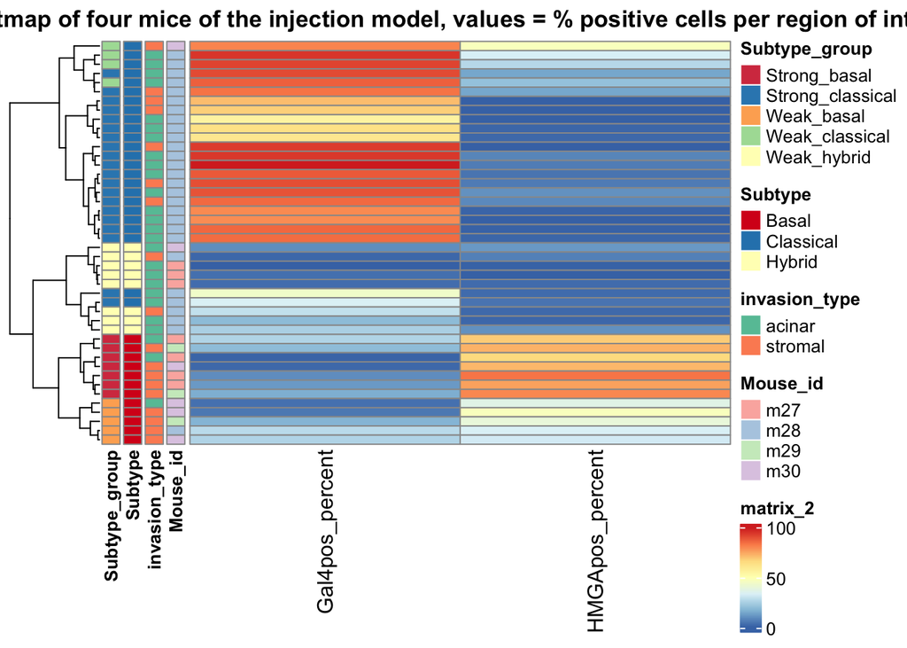

```r
#new metadata matrix with the new subtype info
meta_mheatmap2 <- subtypes
rownames(meta_mheatmap2) <- meta_mheatmap2$Group

meta_mheatmap2$Mouse_id <- paste("m", meta_mheatmap2$Mouse_id, sep = "")
meta_mheatmap2 <- meta_mheatmap2[, -c(3:5, 7)]

#add colors for subtype metadata
meta_colors2 <- list(Mouse_id=c(m27="#fbb4ae", m28="#b3cde3", m29="#ccebc5", m30="#decbe4"),
                    invasion_type=c(acinar = "#66c2a5", stromal = "#fc8d62"),
                    Subtype = c(Classical = "#2b83ba", Basal = "#d7191c", Hybrid = "#ffffbf"),
                    Subtype_group = c(Strong_classical="#3288bd", Weak_classical = "#abdda4",Weak_hybrid="#ffffbf", Strong_basal="#d53e4f", Weak_basal="#fdae61" ))


heatmap_inj <- pheatmap(mheatmat, fontsize_col = 12, annotation_row = meta_mheatmap2, annotation_colors = meta_colors2, show_colnames = TRUE, show_rownames = FALSE, main = "Heatmap of four mice of the injection model, values = % positive cells per region of interest", cluster_cols = FALSE, cluster_rows = TRUE)
heatmap_inj
```